# Titanic Analysis

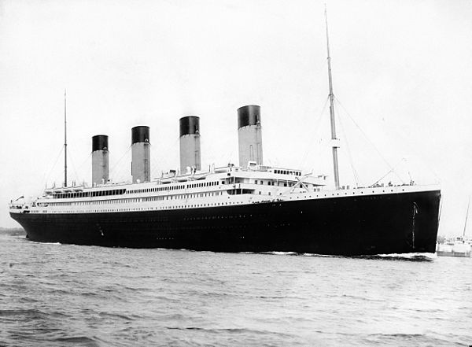

First We created a **.Rprofile txt** document at the same level as our R script to run the needed packages

```r
require("ggplot2")
require("ggthemes")
require("gplots")
require("grid")
require("RCurl")
require("reshape2")
require("rstudio")
require("tableplot")
require("tidyr")
require("dplyr")
require("jsonlite")
require("extrafont")
require("lubridate")
```

Next, we loaded the data frame from the online oracle cloud server using the following code:

```r
df <- data.frame(fromJSON(getURL(URLencode('129.152.144.84:5001/rest/native/?query="select * from titanic"'),httpheader=c(DB='jdbc:oracle:thin:@129.152.144.84:1521/PDBF15DV.usuniversi01134.oraclecloud.internal', USER='cs329e_gmg954', PASS='orcl_gmg954', MODE='native_mode', MODEL='model', returnDimensions = 'False', returnFor = 'JSON'), verbose = TRUE), ))
```

**Summary Statistics** These show the first six items of the dataframe

```r
source("../01 Data/SummaryStats.R", echo = TRUE)
```

```
##
## > require("jsonlite")
##
## > require("RCurl")
##
## > df <- data.frame(fromJSON(getURL(URLencode("129.152.144.84:5001/rest/native/?query=\"select * from titanic where sex is not null\""),
## +     httphea .... [TRUNCATED]
##
## > df
##     PASSENGERID SURVIVED PCLASS
## 1           414        0      2
## 2           415        1      3
## 3           416        0      3
## 4           417        1      2
## 5           418        1      2
```

[output cut: 3619 more lines]

We created five individual R scripts entitled Titanic Analysis num (where num corresponds to the plot number).

The first plot entitled **Rplot1.png** was created using the following R script:

```r
source("../02 Visualizations/Titanic Analysis.R" , echo = TRUE)
```

```
##
## > require("jsonlite")
##
## > require("RCurl")
##
## > df <- data.frame(fromJSON(getURL(URLencode("129.152.144.84:5001/rest/native/?query=\"select * from titanic\""),
## +     httpheader = c(DB = "jdbc:ora ..." ... [TRUNCATED]
##
## > require(extrafont)
##
## > ggplot() + coord_cartesian() + scale_x_continuous() +
## +     scale_y_continuous() + labs(title = "Titanic") + labs(x = "Age",
## +     y = paste("Fare ..." ... [TRUNCATED]
```

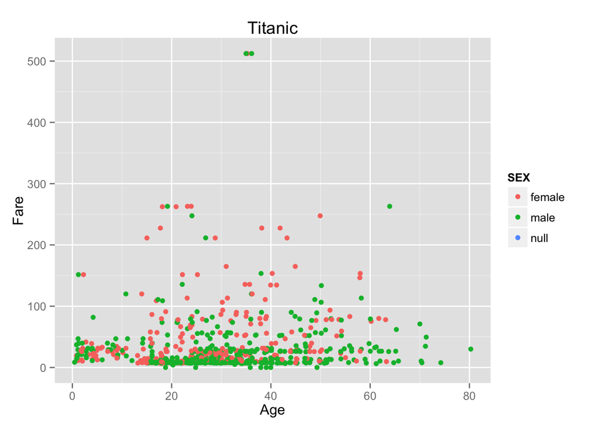

* This first plot above shows the fare that males, females, and null individuals paid*

The second plot entitled **RPlot2.png** was created:

```r
source("../02 Visualizations/Titanic Analysis2.R" , echo = TRUE)
```

```
##
## > require("jsonlite")
##
## > require("RCurl")
##
## > df <- data.frame(fromJSON(getURL(URLencode("129.152.144.84:5001/rest/native/?query=\"select * from titanic where sex is not null\""),
## +     httphea .... [TRUNCATED]
##
## > require(extrafont)
##
## > ggplot() + coord_cartesian() + scale_x_continuous() +
## +     scale_y_continuous() + labs(title = "Titanic") + labs(x = "Age",
## +     y = paste("Fare ..." ... [TRUNCATED]
```

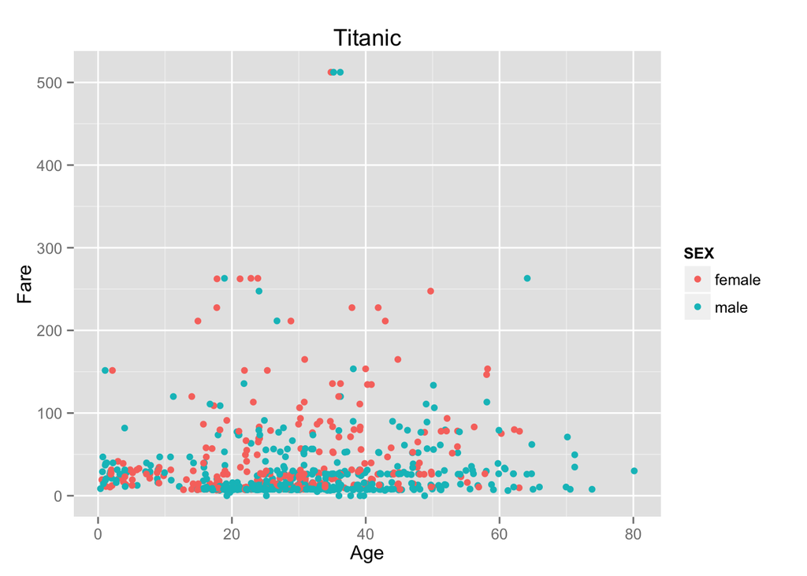

* This second plot shows fare that males and females paid where sex was not classified as null*

The third plot entitled **RPlot3.png** was created:

```r
source("../02 Visualizations/Titanic Analysis3.R" , echo = TRUE)
```

```
##
## > require("jsonlite")
##
## > require("RCurl")
##
## > df <- data.frame(fromJSON(getURL(URLencode("129.152.144.84:5001/rest/native/?query=\"select * from titanic where sex is not null \""),
## +     httphe .... [TRUNCATED]
##
## > require(extrafont)
##
## > ggplot() + coord_cartesian() + scale_x_discrete() +
## +     scale_y_continuous() + labs(title = "Titanic") + labs(x = "SURVIVED",
## +     y = paste("F ..." ... [TRUNCATED]
```

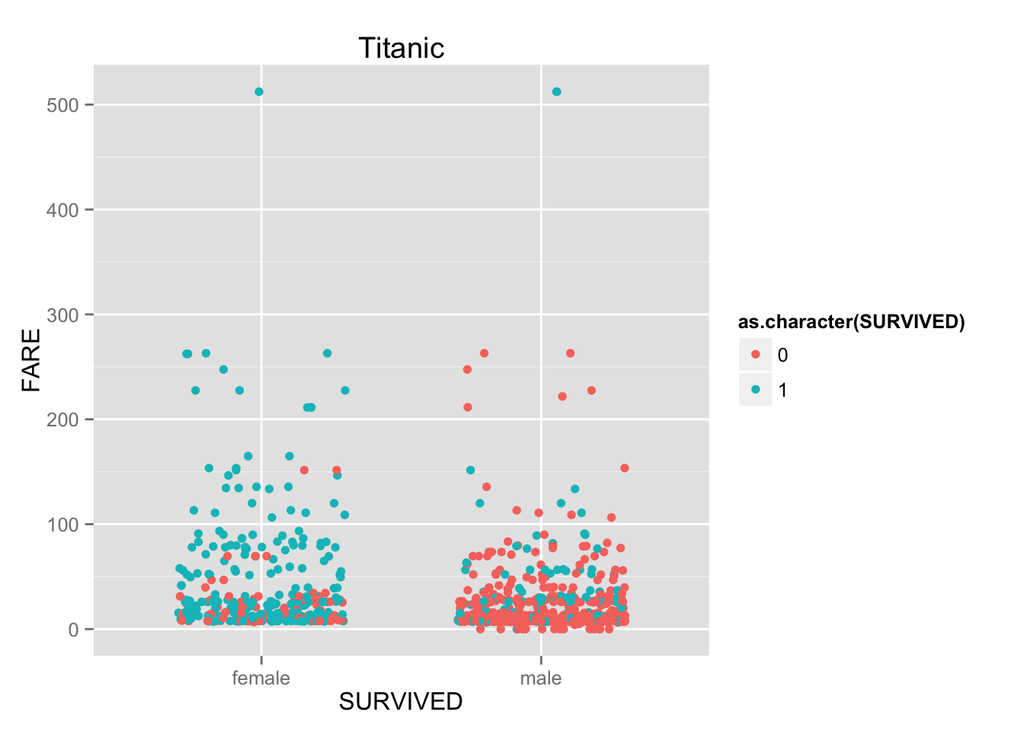

* This thrid plot shows the males and females that survived and did not survive (the legend)* We noticed that more females survived than males did. This may be because females were loaded onto the lifeboats first.

The fourth plot entitled **RPlot4.png** was created:

```r
source("../02 Visualizations/Titanic Analysis4.R" , echo = TRUE)
```

```
##
## > require("jsonlite")
##
## > require("RCurl")
##
## > df <- data.frame(fromJSON(getURL(URLencode("129.152.144.84:5001/rest/native/?query=\"select * from titanic where sex is not null\""),
## +     httphea .... [TRUNCATED]
##
## > require(extrafont)
##
## > ggplot() + coord_cartesian() + scale_x_continuous() +
## +     scale_y_continuous() + labs(title = "Titanic") + labs(x = "Age",
## +     y = paste("Fare ..." ... [TRUNCATED]
```

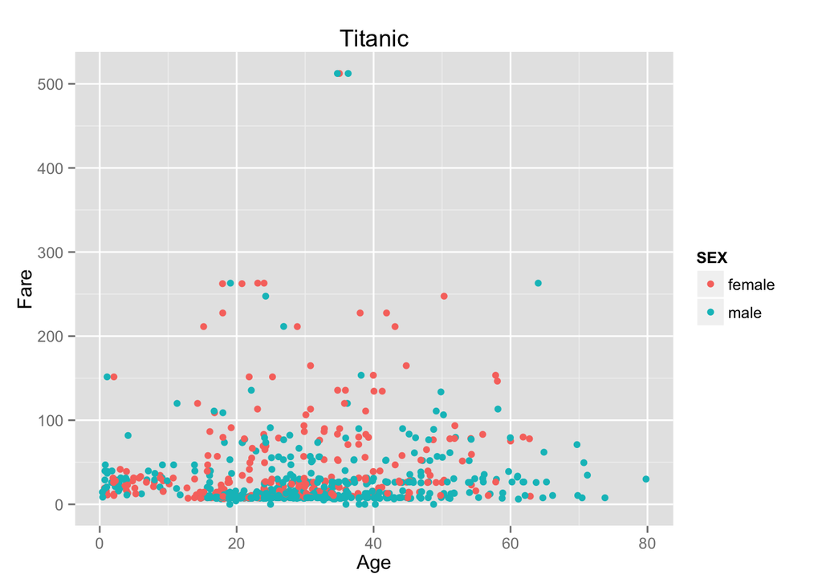

```
##
## > ggplot() + coord_cartesian() + scale_x_discrete() +
## +     scale_y_continuous() + facet_grid(PCLASS ~ SURVIVED, labeller = label_both) +
## +     labs .... [TRUNCATED]
```

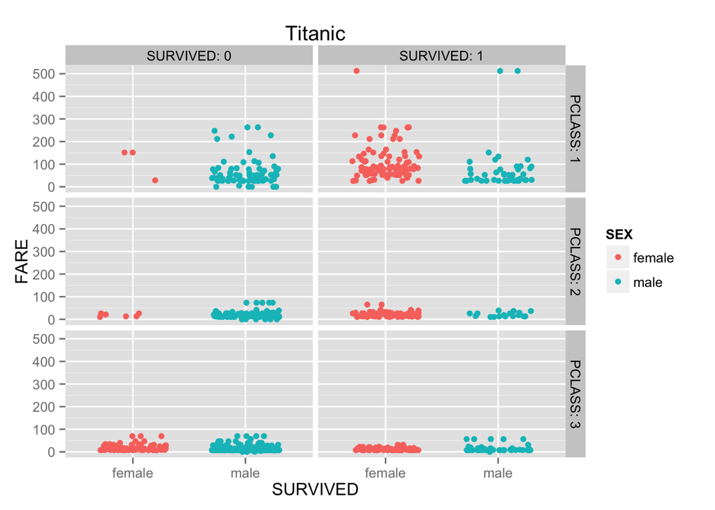

*The plot above shows the females and males (legend) who survived and did not survive according to thier assigned PClass* This graph includes adults and children under the age of ten.

The fifth plot entitled **RPlot5.png** was created:

```r
source("../02 Visualizations/Titanic Analysis5.R" , echo = TRUE)
```

```
##
## > require("jsonlite")
##
## > require("RCurl")
##
## > df <- data.frame(fromJSON(getURL(URLencode("129.152.144.84:5001/rest/native/?query=\"select * from titanic where age <=10 \""),
## +     httpheader =  .... [TRUNCATED]
##
## > require(extrafont)
##
## > ggplot() + coord_cartesian() + scale_x_continuous() +
## +     scale_y_continuous() + labs(title = "Titanic") + labs(x = "Age",
## +     y = paste("Fare ..." ... [TRUNCATED]
```

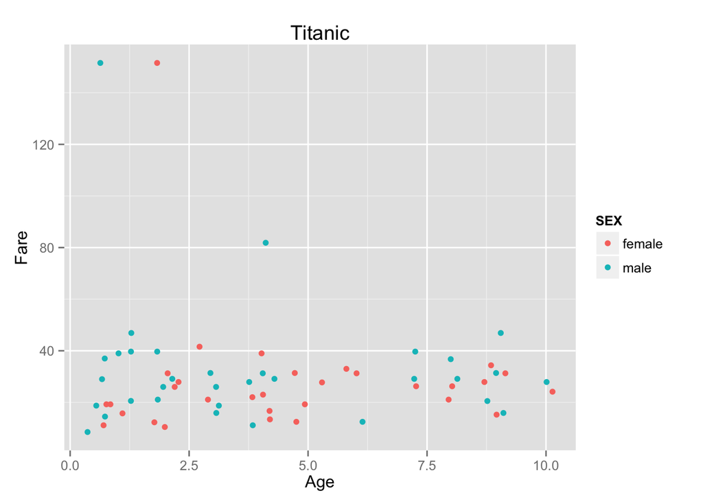

```
##
## > ggplot() + coord_cartesian() + scale_x_discrete() +
## +     scale_y_continuous() + facet_grid(PCLASS ~ SURVIVED, labeller = label_both) +
## +     labs .... [TRUNCATED]
```

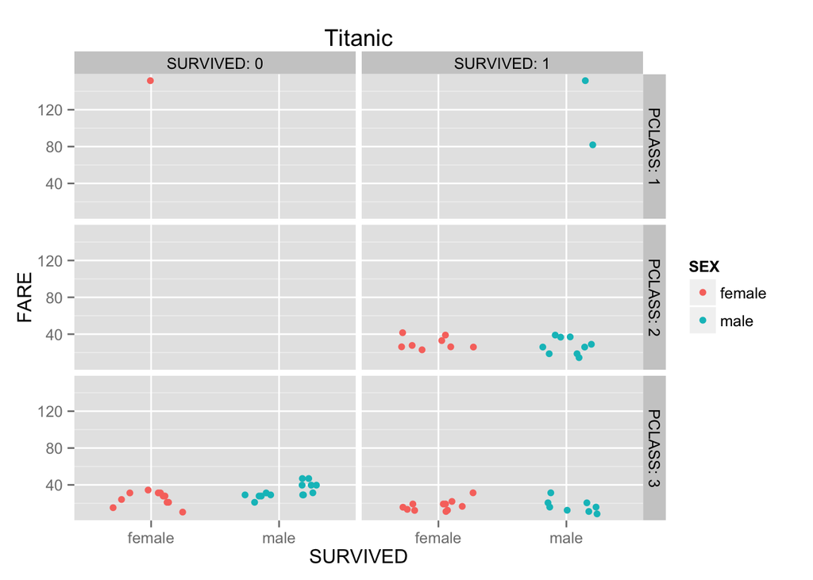

We were prompted to create our own plot that showed data entitles **Extra Analysis.R** The following is the plot we created:

```r
source("../02 Visualizations/Extra Analysis.R" , echo = TRUE)
```

```
##
## > require("ggplot2")
##
## > require("jsonlite")
##
## > require("RCurl")
##
## > df <- data.frame(fromJSON(getURL(URLencode("129.152.144.84:5001/rest/native/?query=\"select * from titanic where survived is not null\""),
## +     ht .... [TRUNCATED]
##
## > require(extrafont)
##
## > ggplot() + coord_cartesian() + scale_y_continuous() +
## +     scale_x_discrete() + labs(title = "Titanic") + labs(t = "Age",
## +     x = paste("Surviv ..." ... [TRUNCATED]
```

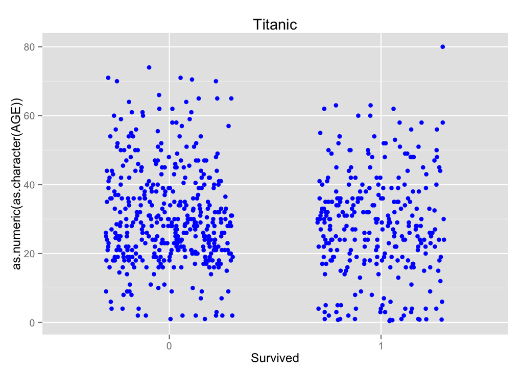

*This plot shows the distribution of survivors and non survivors across the age range from 0 to 80 years. This shows that more people did not survive between the age of 20 to 40 . There was not a large difference in survival rates however it appears that more did not survive than did survive overall.*